# Covid ROPEC Data

Data Partnerships and Innovation Hub

05/10/2020

## Covid-19 data from Robert O. Pickard Environmental Centre,

This file is looking at the ROPEC Covid Data along side the HPOC Covid cases database trying to develop a relationship between the two.

Load source files

```r
source(file.path("utils.r"))
source(file.path("functions.r"))

packages.get(c(
  "cowplot",
  "scales",
  "ggpubr"
))

#theme_set(new = theme_minimal())
```

## Read HPOC Data

```r
df <- read_HPOC_cases_data()

summary(df)
```

## Take a look at some of the NA data

```r
sapply(df, function(x) sum(is.na(x))/length(x))
```

```
##                  onsetdate               reporteddate
##               0.3254668930               0.9764006791
## labspecimencollectiondate1         labtestresultdate1
##               0.1473684211               1.0000000000
##           phacreporteddate               healthregion
##               0.0003395586               0.0000000000
##                         pt               exposure_cat
##               0.0000000000               0.0000000000
##                        age
##               0.0000000000
```

## Imput Deltas

Since there are so many records with missing days we impute the dates that we can. We calculate the diffrences between all dates for cases that have multiple dates

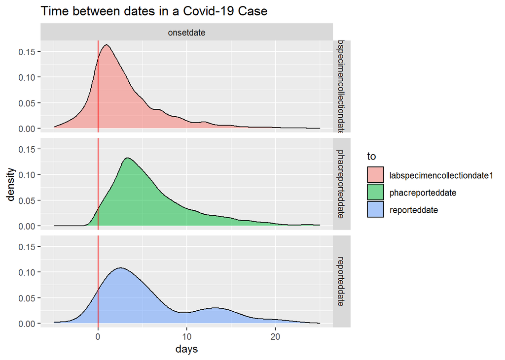

```r
df %>% impute_deltas() %>%
  select(matches("_2_")) %>%
  pivot_longer(1:ncol(.), values_drop_na  = T) %>%
  separate(col = name, into = c("from", "two", "to"),remove =F) %>%
  ggplot(aes(x = value, group = name, fill = to)) +
  geom_density(alpha = 0.5) +
  facet_grid(cols = vars(from), rows = vars(to)) +
  scale_x_continuous(limits = c(-5, 25)) +
  geom_vline(xintercept = 0, color = "red") +
  labs(title = "Time between dates in a Covid-19 Case", x = "days")
```

## Impute the data

We imupute the dates where we do not know using the dates we do know.

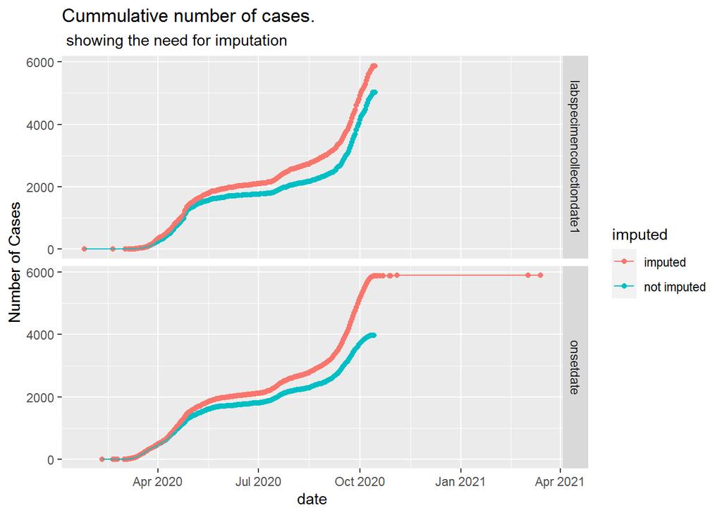

```r
df2 <- df %>% do_impute_on_cols()




df2 %>%
   select(matches("onsetdate"), matches("labspecimencollectiondate")) %>%
   pivot_longer(., 1:ncol(.)) %>%
   separate(name, c("date_type", "imputed"), remove = F) %>%
   replace_na(list(imputed = "not imputed")) %>%
   arrange(value) %>%
   count(name, value, date_type, imputed) %>%
   group_by(name) %>%
   mutate(n_cum = cumsum(n)) %>%
   ggplot(aes(x = value, y = n_cum, color = imputed)) +
   geom_point() +
   geom_line() +
   facet_grid(rows = vars(date_type)) +
   labs(x = "date",
        y = "Number of Cases",
        title = "Cummulative number of cases.",
        subtitle = " showing the need for imputation")
```

## Compare HPOC to other data

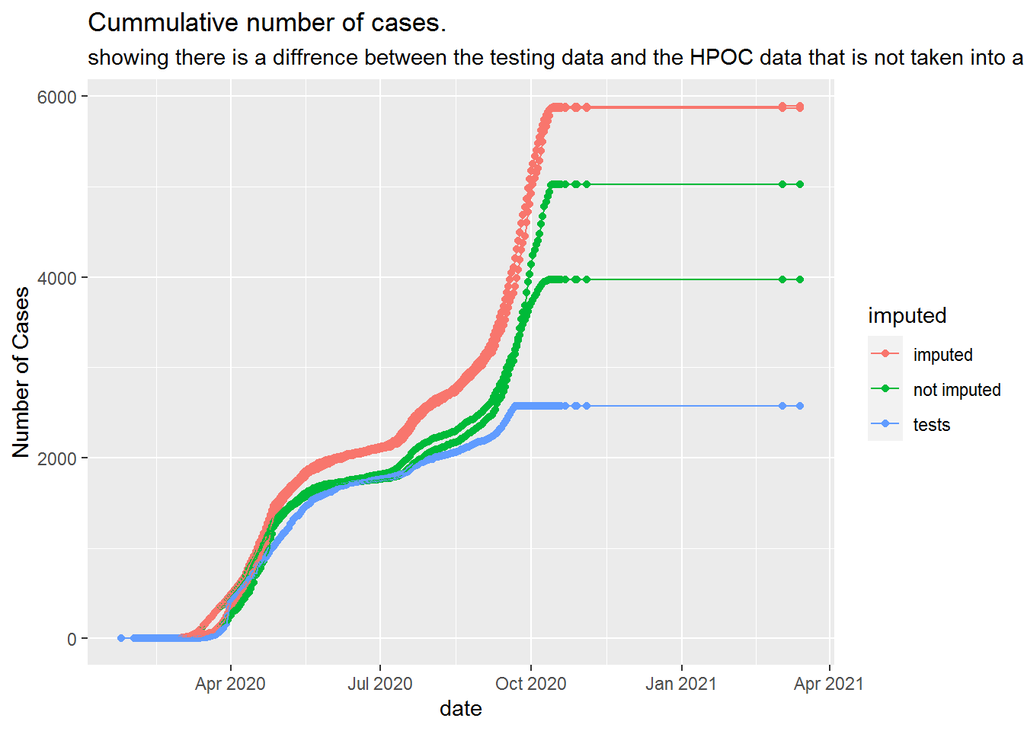

```r
tests <- read_Ottawa_community_data()

df2_b <-
df2 %>%
    select(matches("onsetdate"), matches("labspecimencollectiondate")) %>%
    pivot_longer(., 1:ncol(.)) %>% rename(date := value) %>%
    count(name, date) %>% pivot_wider(names_from = "name", values_from = n, values_fill = 0) %>%
    full_join(tests %>% select(date, postitive_tests), by = "date")



df2_b %>%
    pivot_longer(., 2:ncol(.)) %>%
    separate(name, c("date_type", "imputed"), remove = F) %>%
    replace_na(list(imputed = "not imputed")) %>%
    group_by(name) %>%
    arrange(date) %>%
    replace_na(list(value = 0)) %>%
    mutate(n_cum = cumsum(value)) %>%
    ggplot(aes(x = date, color = imputed, y = n_cum, group = name)) +
    geom_point() +
    geom_line() +
    #facet_grid(rows = vars(date_type)) +
    labs(x = "date",
        y = "Number of Cases",
        title = "Cummulative number of cases.",
        subtitle = "showing there is a diffrence between the testing data and the HPOC data that is not taken into account by imputation")
```

## Adjust by positive test rate

We can adjust the cases by the possitive rate.

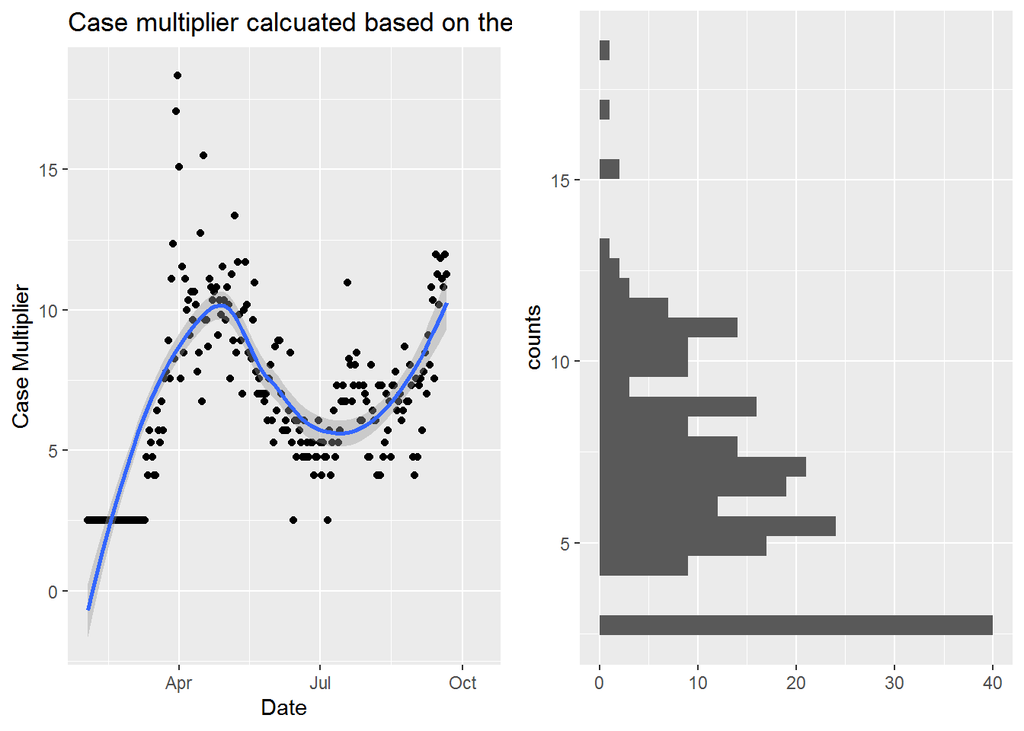

```r
###################
# adjust for tests
tests <- read_Ottawa_community_data()


tests2 <-
  tests %>%
  mutate(case_multiplier = case_multiplyer(postitive_tests/100))



p1 <- tests2 %>%
  ggplot(aes(x = case_multiplier)) + geom_histogram() + coord_flip()  +
  labs(y = "", x = "counts")

p2 <- tests2 %>%
  ggplot(aes(x = date, y = case_multiplier)) + geom_point() + geom_smooth() +
  labs(y = "Case Multiplier", x = "Date", title = "Case multiplier calcuated based on the possitivity rate.")

plot_grid(p2, p1, labels = c('', '') )
```

## DIurnal Cycle at ROPEC

Flows at the waste water treatment plant will change over the course of the day as well as over the course of the year and during rain events.

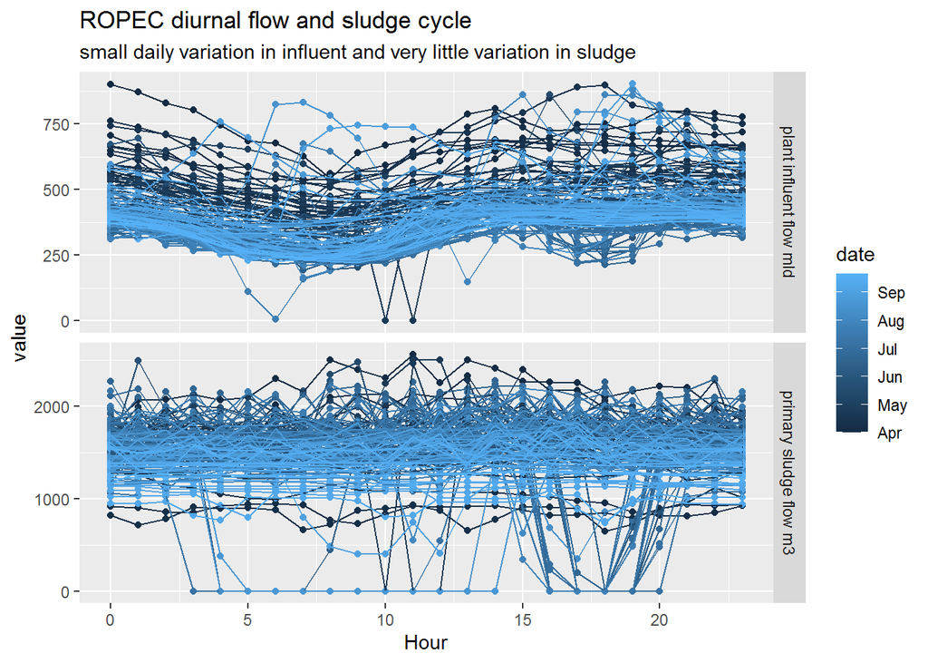

```r
ropec_hourly_flow <- read_sewage_flow_parameters_hourly()

ropec_hourly_flow %>% pivot_longer(cols = c("plant_influent_flow_mld" , "primary_sludge_flow_m3")) %>%
  mutate(name = gsub("_", " ", name)) %>%
  ggplot(aes(x = time, y = value, color = date, group = date)) +
  geom_point() +
  geom_line() +
  facet_grid(row = vars(name), scales = "free_y") +
  labs(x = "Hour", title = "ROPEC diurnal flow and sludge cycle", subtitle = "small daily variation in influent and very little variation in sludge")
```

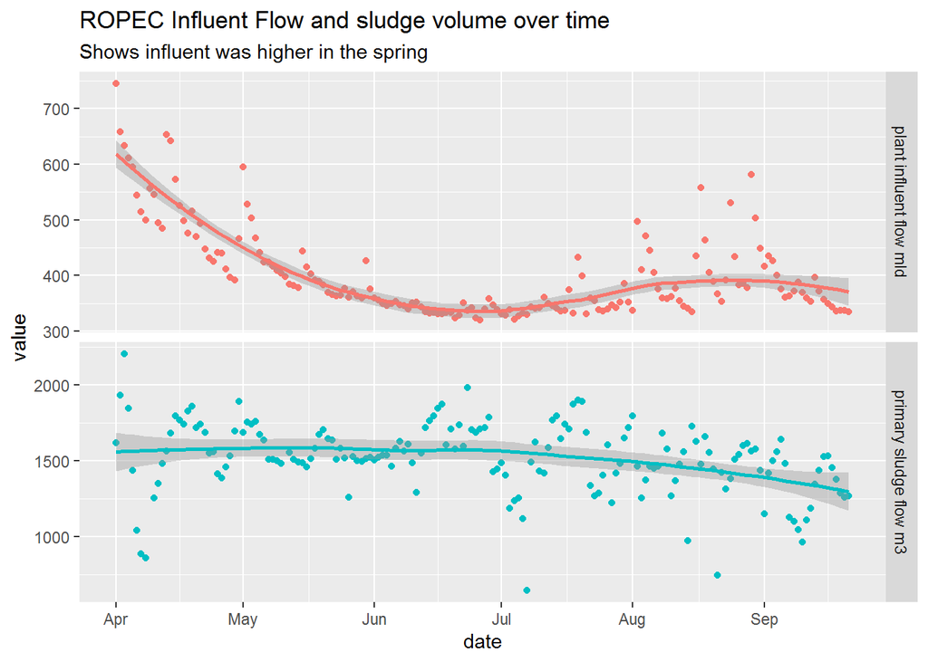

```r
ropec_daily_flow <- read_sewage_flow_parameters_daily()

ropec_daily_flow %>%
  pivot_longer(cols = 2:ncol(.)) %>%
  mutate(name = gsub("_", " ", name)) %>%
  ggplot(aes(x = date, y = value, color = name)) +
  geom_point() +
  geom_smooth() +
  facet_grid(rows = vars(name), scales = "free_y") +
  guides(color = F) +
  labs(title = "ROPEC Influent Flow and sludge volume over time",subtitle = "Shows influent was higher in the spring")
```

## Adjust cases for Infections

Here we estimate infections from cases directly using an adjustment.

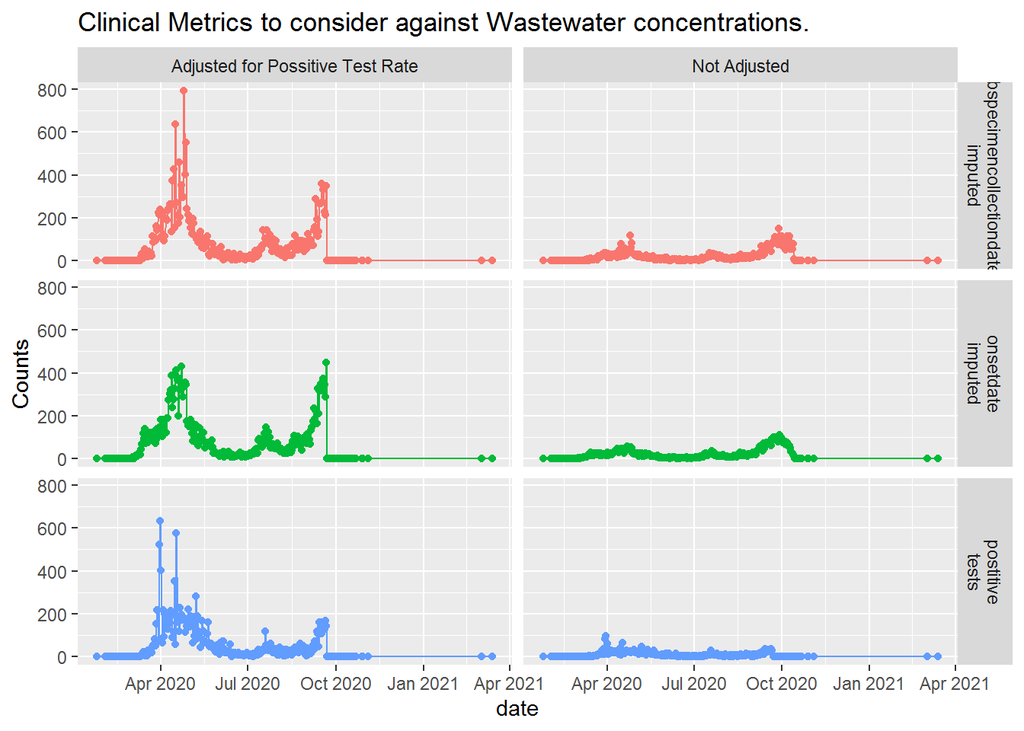

```r
df3 <- df2_b %>%
  adjust_case_by_positive_rate(tests = tests,
                               cols_2_adjust = c(#"labspecimencollectiondate1",
                                                 "labspecimencollectiondate1_imputed",
                                                 #"onsetdate",
                                                 "onsetdate_imputed",
                                                 "postitive_tests" )
                               ) %>%
  rename_at(vars(-date), ~ paste0('pos_Adj_', .)) %>%
  bind_cols(df2_b %>% select(-date)) %>%
  select(-date) %>%
  replace(is.na(.), 0) %>%
  bind_cols(df2_b %>% select(date), .) %>%
  select(date,
         matches("pos_Adj_"),
         postitive_tests,
         pos_Adj_postitive_tests,
         matches("_imputed")
         )


df3 %>%
  pivot_longer(.,2:ncol(.)) %>%
  mutate(IS_ADJUST = ifelse(grepl(pattern = "^pos_Adj", x = name), "Adjusted for Possitive Test Rate", "Not Adjusted")) %>%
  mutate(TYP = gsub(pattern = "^pos_Adj_", replacement = "", x = name)) %>%
  mutate(TYP = gsub(pattern = "_", replacement = "\n", x = TYP)) %>%
  #separate(TYP, c())
  ggplot(aes(x = date, y = value, color = TYP)) +
  geom_point() +
  geom_line()  +
  facet_grid(cols = vars(IS_ADJUST), rows = vars(TYP)) +
  guides(color = F) +
  labs(title = "Clinical Metrics to consider against Wastewater concentrations.", y = "Counts")
```

## Calculate shedding

Literature claims mean shedding happens typically for 17 days after onset in the mean person. Other Literature claims shedding peeks in week 4 after onset.

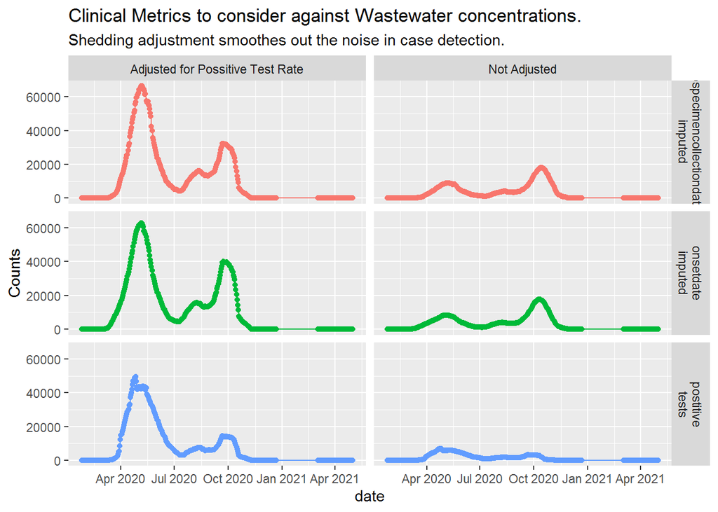

```r
df_shedding <-
  df3 %>% get_shedding()




df_shedding %>% #ggplot(aes(x = date, y = shedding)) + geom_point() + geom_line()
  pivot_longer(., cols = 2:ncol(.)) %>%
  mutate(IS_ADJUST = ifelse(grepl(pattern = "^pos_Adj", x = name), "Adjusted for Possitive Test Rate", "Not Adjusted")) %>%
  mutate(TYP = gsub(pattern = "^pos_Adj_", replacement = "", x = name)) %>%
  mutate(TYP = gsub(pattern = "_", replacement = "\n", x = TYP)) %>%
  ggplot(aes(x = date, y = value, color = TYP)) +
  geom_point() +
  geom_line() +
  facet_grid(cols = vars(IS_ADJUST), rows = vars(TYP)) +
  guides(color = F) +
  labs(title = "Clinical Metrics to consider against Wastewater concentrations.", y = "Counts", subtitle = "Shedding adjustment smoothes out the noise in case detection.")
```

```r
  #facet_grid(rows = vars(name), scales = "free_y")
```

## Cobine Flow Data with Covid Influent Data and Case counts of Ottawa HR

```r
ropec <- read_ropec_data() %>%
  mutate(n_avg = (n1_avg+n2_avg)/2 ) %>%
  mutate(n1_high = (n1_avg+n1_stdev) ) %>%
  mutate(n2_high = (n2_avg+n2_stdev)) %>%
  mutate(n_high = (n1_high+n2_high)/2 ) #%>%
```

```
## [1] "reading from cache C:\\Users\\hswerdfe\\AppData\\Local\\cache/R_tmp_cache/0a307d10abe6ff2b11636c506c44d526.csv"
```

```r
  #mutate(roll_mean = rollmean(x = n1_, 7, na.pad = T, align = "right"))

df_shedding_ropec <-
df_shedding %>%
  full_join(ropec, by = "date")  %>%
  full_join(ropec_daily_flow, by = "date")

# c_nms <- df_shedding_ropec %>% colnames() %>% gsub(pattern = "_", replacement = "\n", x = .)
#
#
#
#
# df_shedding_ropec %>%
#   setNames(., c_nms) %>%
#   GGally::ggpairs()
```

# Relationship between flow rate and n1/n2

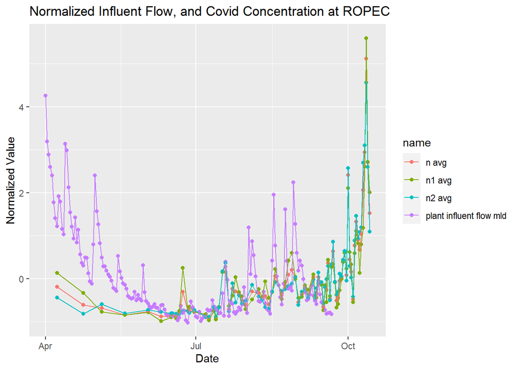

```r
of_intrest <- c("plant_influent_flow_mld", "n_avg", "n1_avg", "n2_avg")

df_shedding_ropec %>%
  select(date, of_intrest) %>%
  pivot_longer(cols = 2:ncol(.), values_drop_na  = T) %>%
  mutate(name = gsub(pattern = "_", replacement = " ", x = name)) %>%
  group_by(name) %>% mutate(value = (value - mean(value, na.rm = T))/ sd(value, na.rm = T)) %>%
  ggplot(aes(x = date, y = value, color = name)) +
  geom_point() +
  geom_line() +
  labs(title = "Normalized Influent Flow, and Covid Concentration at ROPEC", y = "Normalized Value",  x = "Date")
```

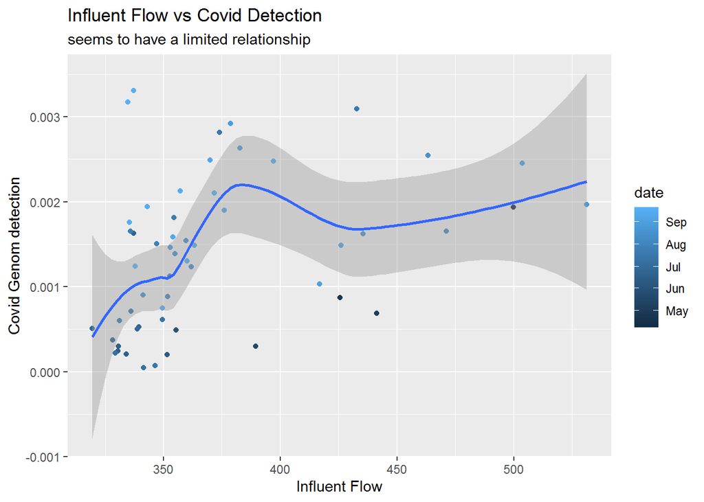

```r
of_intrest <- c("plant_influent_flow_mld", "n_avg", "n1_avg", "n2_avg")

c_nms <- of_intrest %>% gsub(pattern = "_", replacement = "\n", x = .) %>% c("Date", .)


df_shedding_ropec %>%
  select(date, of_intrest) %>%
  filter(! is.na(plant_influent_flow_mld)) %>%
  filter(! is.na(n_avg)) %>%
  ggplot(aes(x = plant_influent_flow_mld, y = n_avg, color = date)) +
  geom_point() +
  geom_smooth() +
  labs(title = "Influent Flow vs Covid Detection", subtitle = "seems to have a limited relationship", x= "Influent Flow", y = "Covid Genom detection")
```

#show time lines for all the data

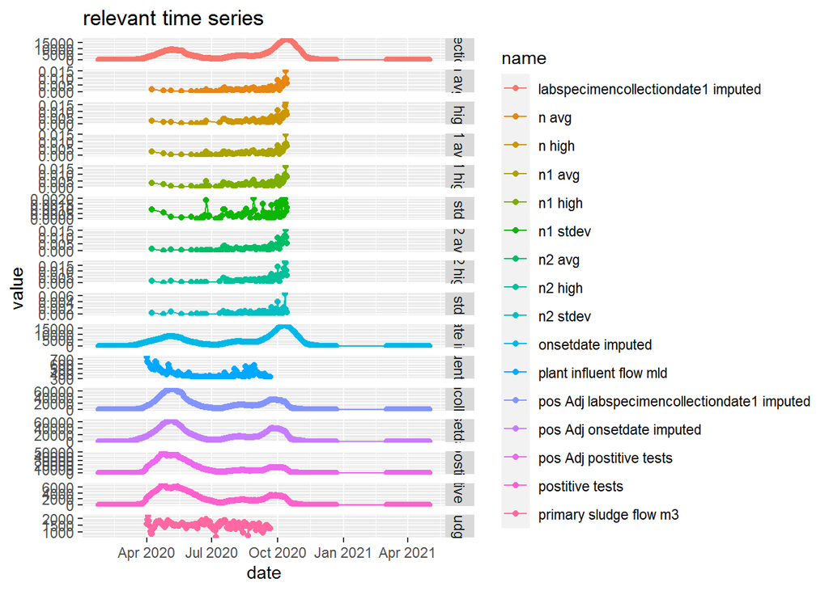

```r
df_shedding_ropec %>%
  pivot_longer(., 2:ncol(.), values_drop_na = T) %>%
  mutate(IS_ADJUST = grepl(pattern = "^pos_Adj", x = name)) %>%
  mutate(TYP = gsub(pattern = "^pos_Adj_", replacement = "", x = name)) %>%
  mutate(TYP = gsub(pattern = "_", replacement = " ", x = TYP)) %>%
  mutate(name = gsub(pattern = "_", replacement = " ", x = name)) %>%
  ggplot(aes(x = date, color = name, y = value))+
  geom_point()+
  geom_line() +
  #facet_grid(cols = vars(IS_ADJUST), rows = vars(TYP), scales = "free_y")
  facet_grid(rows = vars(name), scales = "free_y") +
  labs(title = "relevant time series")
```

## Relationship between N1 and N2

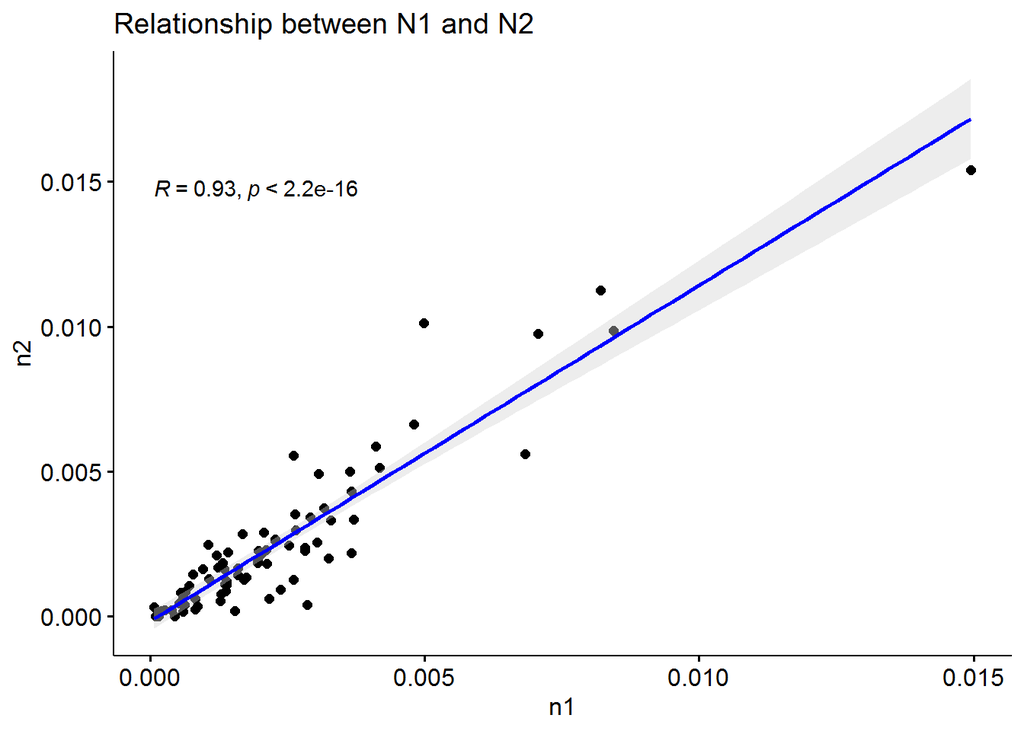

```r
df_shedding_ropec %>%
  ggscatter(x = "n1_avg", y = "n2_avg",
          add = "reg.line",                                 # Add regression line
          conf.int = TRUE,                                  # Add confidence interval
          add.params = list(color = "blue",
                            fill = "lightgray")
          )+
  stat_cor(method = "pearson") +
  labs(title = "Relationship between N1 and N2", x = "n1", y = "n2")
```

Build a single linnear model

```r
df_shedding_ropec <-
  df_shedding_ropec %>%
  mutate(onsetdate_imputed_ln = log_epsilon(onsetdate_imputed)) %>%
  mutate(n_avg_ln = log_epsilon(n_avg))
```

```
## [1] ", in function log_epsilon, epsilon of , 1e-04,  used., "
## [1] ", in function log_epsilon, epsilon of , 1e-04,  used., "
```

```r
mdl_ln_n <-
df_shedding_ropec %>%
  glm(data = .,formula = onsetdate_imputed ~ n_avg_ln)

mdl_ln_n %>% summary()
```

```
##
## Call:
## glm(formula = onsetdate_imputed ~ n_avg_ln, data = .)
##
## Deviance Residuals:
##     Min       1Q   Median       3Q      Max
## -7766.7  -2882.2   -911.9   2955.9  10216.1
##
## Coefficients:
##             Estimate Std. Error t value Pr(>|t|)
## (Intercept)  34711.8     3086.7  11.245  < 2e-16 ***
## n_avg_ln      4298.4      478.5   8.984 1.43e-13 ***
## ---
## Signif. codes:  0 '***' 0.001 '**' 0.01 '*' 0.05 '.' 0.1 ' ' 1
##
## (Dispersion parameter for gaussian family taken to be 15260797)
##
##     Null deviance: 2391502702  on 77  degrees of freedom
## Residual deviance: 1159820563  on 76  degrees of freedom
##   (316 observations deleted due to missingness)
## AIC: 1515.5
##
## Number of Fisher Scoring iterations: 2
```

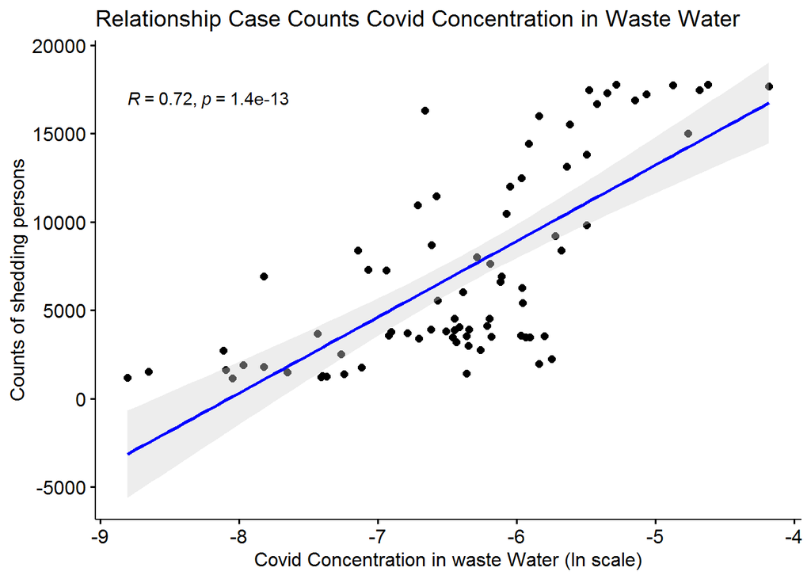

```r
df_shedding_ropec %>%
  select(date, n_avg,n_avg_ln, onsetdate_imputed_ln, onsetdate_imputed) %>%
  filter( ! is.na(n_avg)) %>%
  ggscatter(x = "n_avg_ln", y = "onsetdate_imputed",
          add = "reg.line",                                 # Add regression line
          conf.int = TRUE,                                  # Add confidence interval
          add.params = list(color = "blue",
                            fill = "lightgray")
          )+
  stat_cor(method = "pearson") +
  labs(title = "Relationship Case Counts Covid Concentration in Waste Water",
       x = "Covid Concentration in waste Water (ln scale)", y = "Counts of shedding persons")
```